# Stock_markets_analysis

```python
import numpy as np
import pandas as pd
import matplotlib.pyplot as plt
%matplotlib inline
```

```python
import pandas_datareader
import datetime
import pandas_datareader.data as web
```

```python
start = datetime.datetime(2012,1,1)
end = datetime.datetime(2017,1,1)
```

```python
tesla = pd.read_csv('Tesla_Stock.csv')
tesla.set_index(['Date'], inplace=True)
tesla.index = pd.to_datetime(tesla.index)
```

```python
tesla.head()
```

| Date | Open | High | Low | Close | Volume |
| --- | --- | --- | --- | --- | --- |
| 2012-01-03 | 28.94 | 29.50 | 27.65 | 28.08 | 928052 |
| 2012-01-04 | 28.21 | 28.67 | 27.50 | 27.71 | 630036 |
| 2012-01-05 | 27.76 | 27.93 | 26.85 | 27.12 | 1005432 |
| 2012-01-06 | 27.20 | 27.79 | 26.41 | 26.89 | 687081 |
| 2012-01-09 | 27.00 | 27.49 | 26.12 | 27.25 | 896951 |

```python
ford = pd.read_csv('Ford_Stock.csv')
ford.set_index(['Date'], inplace=True)
ford.index = pd.to_datetime(ford.index)
```

```python
ford.head()
```

| Date | Open | High | Low | Close | Volume |
| --- | --- | --- | --- | --- | --- |
| 2012-01-03 | 11.00 | 11.25 | 10.99 | 11.13 | 45709811 |
| 2012-01-04 | 11.15 | 11.53 | 11.07 | 11.30 | 79725188 |
| 2012-01-05 | 11.33 | 11.63 | 11.24 | 11.59 | 67877467 |
| 2012-01-06 | 11.74 | 11.80 | 11.52 | 11.71 | 59840605 |
| 2012-01-09 | 11.83 | 11.95 | 11.70 | 11.80 | 53981467 |

```python
gm = pd.read_csv('GM_Stock.csv')
gm.set_index(['Date'], inplace=True)
gm.index = pd.to_datetime(gm.index)
```

```python
gm.head()
```

| Date | Open | High | Low | Close | Volume |
| --- | --- | --- | --- | --- | --- |
| 2012-01-03 | 20.83 | 21.18 | 20.75 | 21.05 | 9321420 |
| 2012-01-04 | 21.05 | 21.37 | 20.75 | 21.15 | 7856752 |
| 2012-01-05 | 21.10 | 22.29 | 20.96 | 22.17 | 17884040 |
| 2012-01-06 | 22.26 | 23.03 | 22.24 | 22.92 | 18234608 |
| 2012-01-09 | 23.20 | 23.43 | 22.70 | 22.84 | 12091714 |

### Plot the volume of stock traded each day

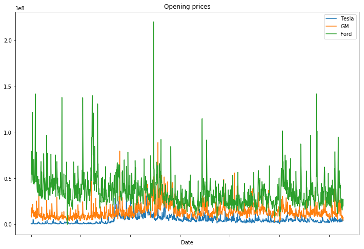

```python
tesla['Volume'].plot(label='Tesla',figsize=(12,8),title='Opening prices')
gm['Volume'].plot(label='GM')
ford['Volume'].plot(label='Ford')
plt.legend();
```

#### Ford had a big spike on 18 december 2013

```python
ford['Volume'].idxmax()
```

```
'2013-12-18'
```

```python
tesla['Total traded'] = tesla['Open']*tesla['Volume']
ford['Total traded'] = ford['Open']*ford['Volume']
gm['Total traded'] = gm['Open']*gm['Volume']
```

#### Plot total traded volume against the time index

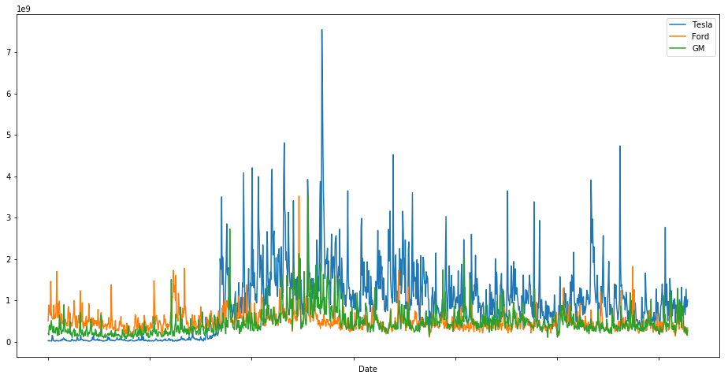

```python
tesla['Total traded'].plot(label='Tesla',figsize=(16,8))
ford['Total traded'].plot(label='Ford',figsize=(16,8))
gm['Total traded'].plot(label='GM',figsize=(16,8))
plt.legend();
```

### Moving averages

```python
gm['MA50'] = gm['Open'].rolling(50).mean()
```

```python
gm['MA200'] = gm['Open'].rolling(200).mean()
```

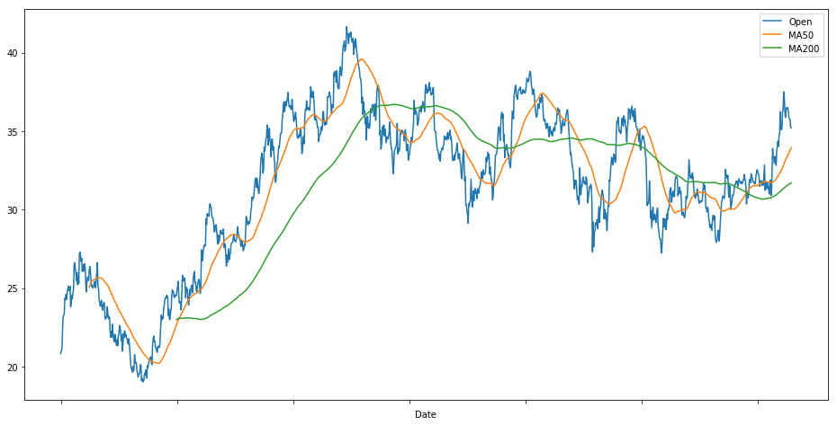

```python
gm[['Open','MA50','MA200']].plot(figsize=(16,8))
plt.legend();
```

### Plotting a scatter matrix plot to find the relationship between these different car stocks. Plot scatter matrix for all the stocks' opening prices

```python
from pandas.plotting import scatter_matrix
```

```python
car_comp = pd.concat([tesla['Open'],gm['Open'],ford['Open']],axis = 1)
```

```python
car_comp.columns = ['Tesla Open','GM Open','Ford Open']
```

```python
car_comp.head()
```

| Date | Tesla Open | GM Open | Ford Open |
| --- | --- | --- | --- |
| 2012-01-03 | 28.94 | 20.83 | 11.00 |
| 2012-01-04 | 28.21 | 21.05 | 11.15 |
| 2012-01-05 | 27.76 | 21.10 | 11.33 |
| 2012-01-06 | 27.20 | 22.26 | 11.74 |
| 2012-01-09 | 27.00 | 23.20 | 11.83 |

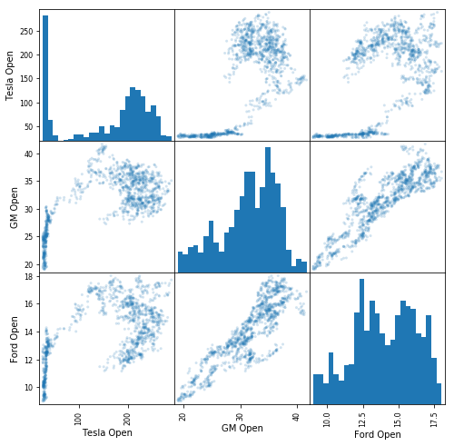

```python
scatter_matrix(car_comp,figsize=(8,8),alpha=0.2,hist_kwds={'bins':25});
```

### Conclusion #1: Looks like Ford and GM are largely similar given their positive correlation

```python
from matplotlib.finance import candlestick_ohlc
from matplotlib.dates import DateFormatter,date2num,WeekdayLocator,DayLocator,MONDAY
```

#### Matplotlib doesn't do a very good job of interpreting date values directly for time series analysis( the irony!) hence converting date values to numeric ones

```python
ford_reset = ford.loc['2012-01'].reset_index()
```

```python
ford_reset.info()
```

```
<class 'pandas.core.frame.DataFrame'>
RangeIndex: 20 entries, 0 to 19
Data columns (total 6 columns):
Date      20 non-null datetime64[ns]
Open      20 non-null float64
High      20 non-null float64
Low       20 non-null float64
Close     20 non-null float64
Volume    20 non-null int64
dtypes: datetime64[ns](1), float64(4), int64(1)
memory usage: 1.0 KB
```

```python
ford_reset['date_ax'] = ford_reset['Date'].apply(lambda date:date2num(date))
```

```python
ford_reset.head()
```

|  | Date | Open | High | Low | Close | Volume | date_ax |
| --- | --- | --- | --- | --- | --- | --- | --- |
| 0 | 2012-01-03 | 11.00 | 11.25 | 10.99 | 11.13 | 45709811 | 734505.0 |
| 1 | 2012-01-04 | 11.15 | 11.53 | 11.07 | 11.30 | 79725188 | 734506.0 |
| 2 | 2012-01-05 | 11.33 | 11.63 | 11.24 | 11.59 | 67877467 | 734507.0 |
| 3 | 2012-01-06 | 11.74 | 11.80 | 11.52 | 11.71 | 59840605 | 734508.0 |
| 4 | 2012-01-09 | 11.83 | 11.95 | 11.70 | 11.80 | 53981467 | 734511.0 |

## Daily Percentage Change

First we will begin by calculating the daily percentage change. Daily percentage change is defined by the following formula:

$ r_t = \frac{p_t}{p_{t-1}} -1$

This defines r_t (return at time t) as equal to the price at time t divided by the price at time t-1 (the previous day) minus 1. Basically this just informs you of your percent gain (or loss) if you bought the stock on day and then sold it the next day. While this isn't necessarily helpful for attempting to predict future values of the stock, its very helpful in analyzing the volatility of the stock. If daily returns have a wide distribution, the stock is more volatile from one day to the next. Let's calculate the percent returns and then plot them with a histogram, and decide which stock is the most stable!

```python
list_of_cols = ['date_ax', 'Open', 'High', 'Low', 'Close']
```

```python
ford_values = [tuple(vals) for vals in ford_reset[list_of_cols].values]
```

```python
mondays = WeekdayLocator(MONDAY)
alldays = DayLocator()
weekFormatter = DateFormatter('%b %d')
dayFormatter = DateFormatter('%d')
```

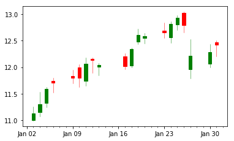

```python
fig, ax = plt.subplots()
fig.subplots_adjust(bottom=0.2)
ax.xaxis.set_major_locator(mondays)
ax.xaxis.set_minor_locator(alldays)
ax.xaxis.set_major_formatter(weekFormatter)
candlestick_ohlc(ax,ford_values, width=0.5, colorup='g',colordown='r');
```

```python
tesla['returns'] = (tesla['Close'] / tesla['Close'].shift(1)) - 1
```

```python
gm['returns'] = (gm['Close'] / gm['Close'].shift(1)) - 1
ford['returns'] = (ford['Close'] / ford['Close'].shift(1)) - 1
```

### Which stock is more volatile? This can be answered using Histogram by judging the variance of the distribution

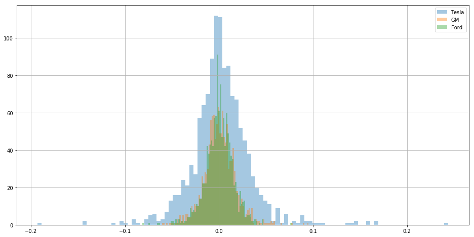

```python
tesla['returns'].hist(bins=100,label='Tesla',figsize=(16,8),alpha=0.4)
gm['returns'].hist(bins=100,label='GM',figsize=(16,8),alpha=0.4)
ford['returns'].hist(bins=100,label='Ford',figsize=(16,8), alpha=0.4)
plt.legend();
```

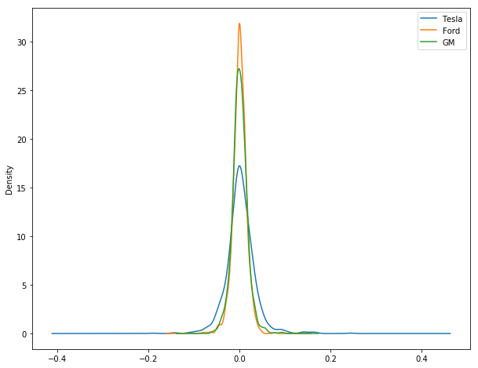

```python
tesla['returns'].plot(kind='KDE',label='Tesla',figsize=(10,8))
ford['returns'].plot(kind='KDE',label='Ford',figsize=(10,8))
gm['returns'].plot(kind='KDE',label='GM',figsize=(10,8))
plt.legend();
```

### KDE plot again shows that Ford stocks tend to more towards the normal and tesla being most volatile with the widest distribution range

```python
box_df = pd.concat([tesla['returns'], ford['returns'], gm['returns']], axis=1)
```

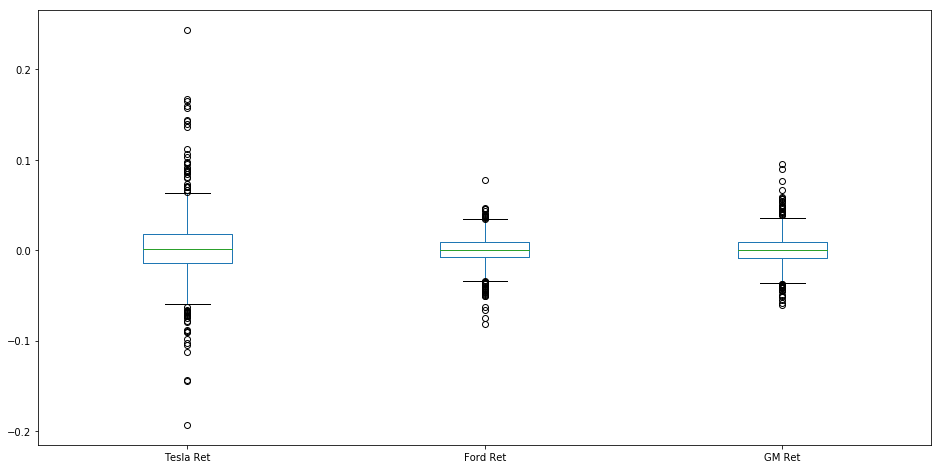

```python
box_df.columns = ['Tesla Ret' , 'Ford Ret', 'GM Ret']
box_df.plot(kind='box', figsize=(16,8))
```

### Conclusion #2 : Tesla is a different animal altogether with more volatility compared to the other two stocks. Ford tends to be more stable.

## Comparing Daily Returns between Stocks

**Create a scatter matrix plot to see the correlation between each of the stocks daily returns. This helps answer the questions of how related the car companies are. Is Tesla begin treated more as a technology company rather than a car company by the market?**

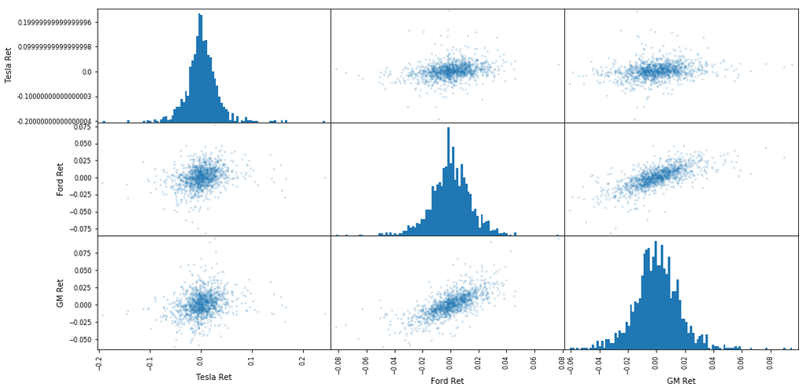

```python
scatter_matrix(box_df, figsize=(16,8), alpha=0.2, hist_kwds={'bins':100});
```

**It looks like Ford and GM do have some sort of possible relationship, let's plot just these two against eachother in scatter plot to view this more closely!**

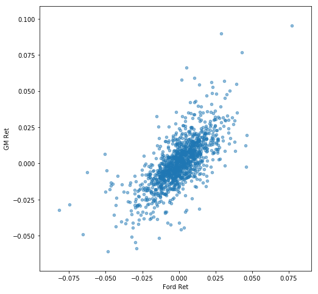

```python
box_df.plot(kind='scatter',x='Ford Ret',y='GM Ret',alpha=0.5,figsize=(8,8));
```

## Cumulative Daily Returns

With daily cumulative returns, the question we are trying to answer is the following, if I invested $1 in the company at the beginning of the time series, how much would is be worth today? This is different than just the stock price at the current day, because it will take into account the daily returns. Keep in mind, our simple calculation here won't take into account stocks that give back a dividend.

The formula for a cumulative daily return is:

$ i_i = (1+r_t) * i_{t-1} $

Here we can see we are just multiplying our previous investment at i at t-1 by 1+our percent returns. Pandas makes this very simple to calculate with its cumprod() method. Using something in the following manner:

```
df[daily_cumulative_return] = ( 1 + df[pct_daily_return] ).cumprod()
```

```python
tesla['Cumulative return'] = (1+tesla['returns']).cumprod()
ford['Cumulative return'] = (1+ford['returns']).cumprod()
gm['Cumulative return'] = (1+gm['returns']).cumprod()
```

**Now plot the Cumulative Return columns against the time series index. Which stock showed the highest return for a $1 invested? Which showed the lowest?**

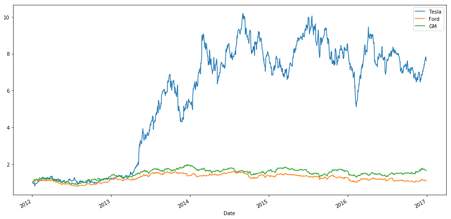

```python
tesla['Cumulative return'].plot(label='Tesla',figsize=(16,8))
ford['Cumulative return'].plot(label='Ford',figsize=(16,8))
gm['Cumulative return'].plot(label='GM',figsize=(16,8))
plt.legend();
```

**Commenting the tesla graph to show cumulative returns for Ford and GM more clearly**

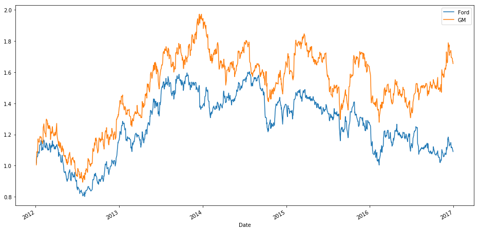

```python
ford['Cumulative return'].plot(label='Ford',figsize=(16,8))
gm['Cumulative return'].plot(label='GM',figsize=(16,8))
plt.legend();
```

### Conclusion #3 : Tesla though not as stable as Ford and GM is much more investor friendly in the long run with large cumulative returns for money invested.